# Q & K Box 15.2

Lemmens et al. (2015) did a detailed study of various biotic communities in artificial ponds in Belgium. They sampled 28 ponds that represented different types of management, a combination of fish farming strategies (no fish, farming young fish, low intensity management, no management), and drainage frequencies (> 10 years ago, occasional, annual). They also quantified taxon abundances for fish, zooplankton, and macro-invertebrates (different families and species within some groups) and covers of submerged, floating, and emergent vegetation. The macroinvertebrate dataset only included 23 ponds and we will use these data to illustrate CA by examining the ordination of the macroinvertebrate community (abundances of families).

The paper is [here](https://doi.org/10.1371/journal.pone.0139371) and the pond subset for this example is lemminvert2.csv

Lemmens, P., Mergeay, J., Van Wichelen, J., De Meester, L. & Declerck, S. A. (2015). The impact of conservation management on the community composition of multiple organism groups in eutrophic interconnected man-made ponds. *PLoS One*, 10, e0139371.

### Preliminaries

Plots used for QK use the ggplot classic theme, with some tweaks. Tweaks are consolidated into theme_QK; use this theme for figures and tweak the theme to avoid repetitive code changes.

packages: vegan

## do CA using vegan

Convert data to contingency table

Get chi-square test of independence

```r
lemminvert <- read_csv("../data/lemminvert2.csv")
lemminvert1.tab <- as.table(as.matrix(lemminvert[,-(1:3)]))
chisq.test(lemminvert1.tab,correct=F)
```

```
    Pearson's Chi-squared test

data:  lemminvert1.tab
X-squared = 24485.276, df = 616, p-value < 2.2204e-16
```

Very low P value

```r
lemminvert1 <- lemminvert[,-(1:3)]
lemmens1.ca <- cca(lemminvert1)
summary(lemmens1.ca, scaling=1)
```

```
Call:
cca(X = lemminvert1)

Partitioning of scaled Chi-square:
               Inertia Proportion
Total         1.306439          1
Unconstrained 1.306439          1

Eigenvalues, and their contribution to the scaled Chi-square

Importance of components:
                            CA1       CA2       CA3       CA4        CA5        CA6
Eigenvalue            0.3646027 0.1563418 0.1471454 0.1350028 0.12477099 0.09851886
Proportion Explained  0.2790813 0.1196702 0.1126309 0.1033365 0.09550466 0.07541024
Cumulative Proportion 0.2790813 0.3987515 0.5113824 0.6147189 0.71022356 0.78563380
                             CA7        CA8        CA9       CA10       CA11
Eigenvalue            0.08073187 0.04604113 0.04071200 0.03138836 0.02620429
Proportion Explained  0.06179537 0.03524170 0.03116258 0.02402589 0.02005780
Cumulative Proportion 0.84742917 0.88267087 0.91383345 0.93785935 0.95791715
                            CA12       CA13        CA14        CA15        CA16
Eigenvalue            0.01864224 0.01378977 0.006884844 0.005143572 0.004453789
Proportion Explained  0.01426951 0.01055523 0.005269932 0.003937094 0.003409106
Cumulative Proportion 0.97218665 0.98274189 0.988011820 0.991948913 0.995358020
                             CA17         CA18         CA19         CA20
Eigenvalue            0.003260623 0.0011283312 0.0008856922 0.0005362529
Proportion Explained  0.002495810 0.0008636694 0.0006779439 0.0004104692
Cumulative Proportion 0.997853830 0.9987174993 0.9993954433 0.9998059125
                              CA21         CA22
Eigenvalue            0.0001551241 9.843940e-05
Proportion Explained  0.0001187381 7.534941e-05
Cumulative Proportion 0.9999246506 1.000000e+00
```

```r
summary(lemmens1.ca, scaling=2)
```

```
Call:
cca(X = lemminvert1)

Partitioning of scaled Chi-square:
               Inertia Proportion
Total         1.306439          1
Unconstrained 1.306439          1

Eigenvalues, and their contribution to the scaled Chi-square

Importance of components:
                            CA1       CA2       CA3       CA4        CA5        CA6
Eigenvalue            0.3646027 0.1563418 0.1471454 0.1350028 0.12477099 0.09851886
Proportion Explained  0.2790813 0.1196702 0.1126309 0.1033365 0.09550466 0.07541024
Cumulative Proportion 0.2790813 0.3987515 0.5113824 0.6147189 0.71022356 0.78563380
                             CA7        CA8        CA9       CA10       CA11
Eigenvalue            0.08073187 0.04604113 0.04071200 0.03138836 0.02620429
Proportion Explained  0.06179537 0.03524170 0.03116258 0.02402589 0.02005780
Cumulative Proportion 0.84742917 0.88267087 0.91383345 0.93785935 0.95791715
                            CA12       CA13        CA14        CA15        CA16
Eigenvalue            0.01864224 0.01378977 0.006884844 0.005143572 0.004453789
Proportion Explained  0.01426951 0.01055523 0.005269932 0.003937094 0.003409106
Cumulative Proportion 0.97218665 0.98274189 0.988011820 0.991948913 0.995358020
                             CA17         CA18         CA19         CA20
Eigenvalue            0.003260623 0.0011283312 0.0008856922 0.0005362529
Proportion Explained  0.002495810 0.0008636694 0.0006779439 0.0004104692
Cumulative Proportion 0.997853830 0.9987174993 0.9993954433 0.9998059125
                              CA21         CA22
Eigenvalue            0.0001551241 9.843940e-05
Proportion Explained  0.0001187381 7.534941e-05
Cumulative Proportion 0.9999246506 1.000000e+00
```

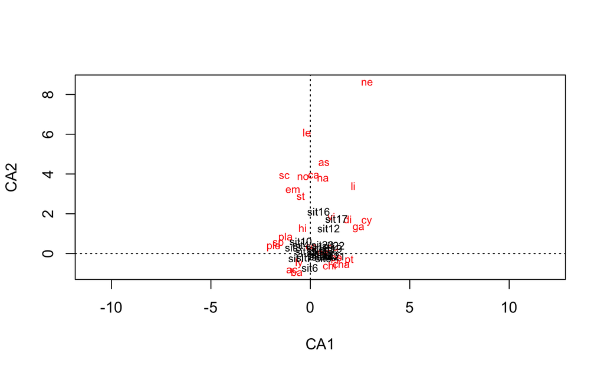

```r
ordiplot(lemmens1.ca, scaling=1, type="text")
```

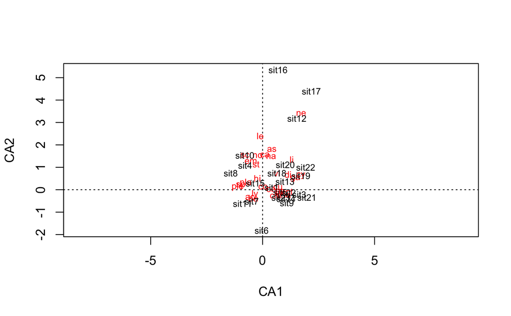

```r
ordiplot(lemmens1.ca, scaling=2, type="text")
```

Get broken stick graphs

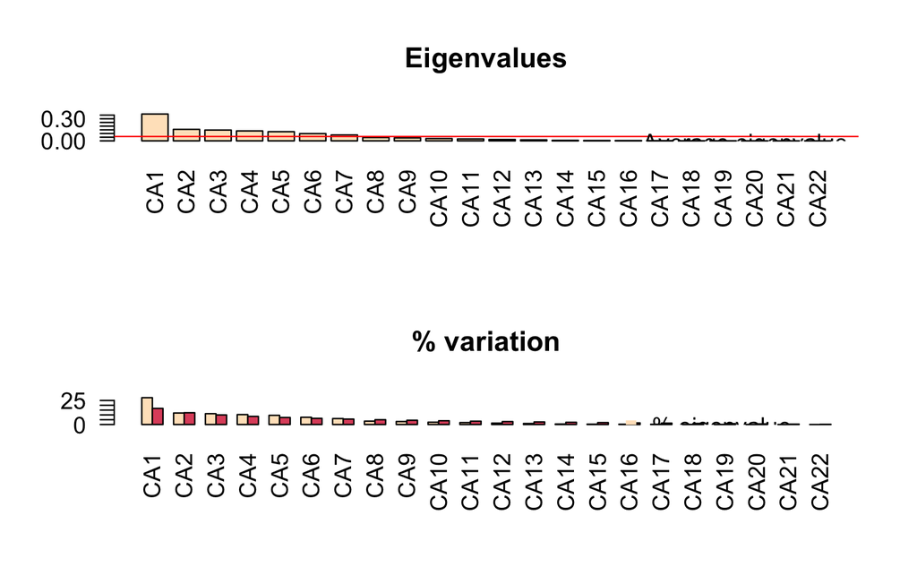

```r
lemmens1.ca.eig <- lemmens1.ca$CA$eig
evplot(lemmens1.ca.eig)
```

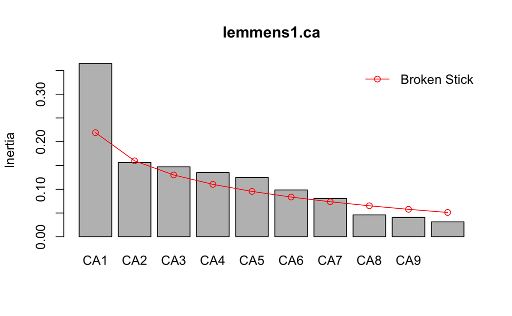

```r
screeplot(lemmens1.ca,bstick=TRUE)
```

Do nice biplots

```r
library(ggrepel)
#extract scores into smaller file.show
a<-as.data.frame(lemmens1.ca$CA$u) #u is sites
b<-as.data.frame(lemmens1.ca$CA$v)    #v is variables
b$fam<-row.names(b)    #add family names for plotting
a<-cbind(lemminvert[c(1:3)],a)   #Add site names & symbols from original data file
br=c("nm","li","nf","yf")
la=c("None", "Light", "No fish", "Young fish")
p1a<-ggplot(data=b, aes(x=CA1, y=CA2))+
  geom_point()+
  geom_text_repel(aes(label=fam), size=2, max.overlaps=25)+
  theme_qk()+
  xlim(-2,3)+
  ylim(-2,10)
p2<-ggplot(data=a, aes(x=CA1, y=CA2, shape=manag, ) )+
  geom_point()+
  labs(y=NULL)+
  scale_shape_manual(values=sym4,
                     name="Management",
                     breaks=br,
                     labels=la,
                     guide =
                         guide_legend(label.theme = element_text(size=6),
                                    title=NULL)
                     )+
  xlim(-2,3)+
  ylim(-2,10)+
  theme_qk()
p3<-p1a+p2
```

|  | t | l | b | r |
| --- | --- | --- | --- | --- |
| 1: | 1 | 1 | 1 | 1 |
| 2: | 1 | 2 | 1 | 2 |

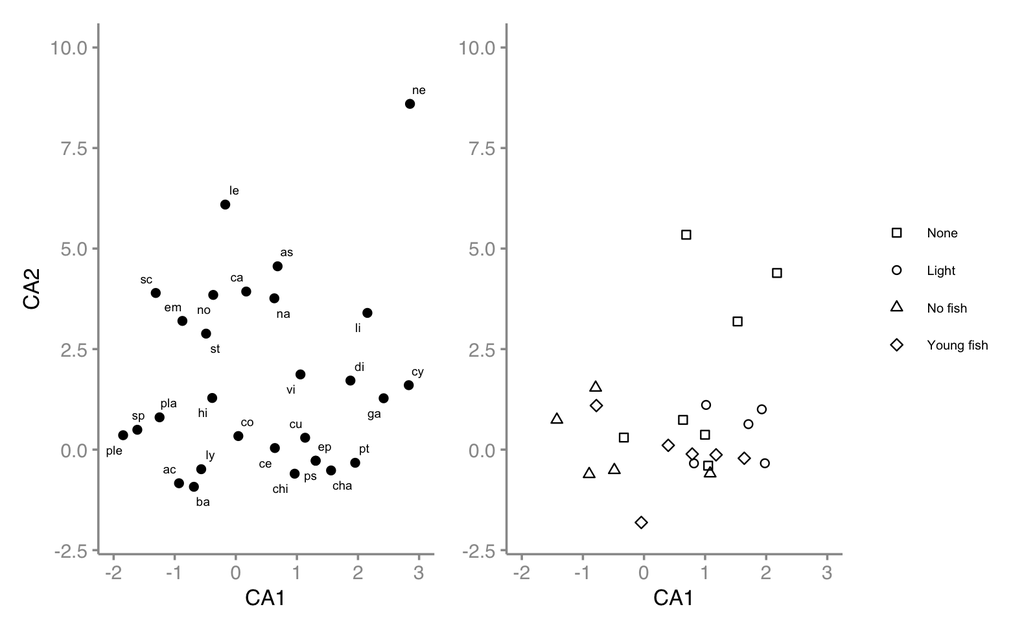

```r
p3
```

Colour version of RH panel

```r
p2a<-ggplot(data=a, aes(x=CA1, y=CA2, color=manag, ) )+
  geom_point()+
  labs(y=NULL)+
  scale_color_viridis_d(
                     name="Management",
                     breaks=br,
                     labels=la,
                     guide =
                         guide_legend(label.theme = element_text(size=6),
                                    title=NULL)
                     )+
    xlim(-2,3)+
  ylim(-2,10)+
  theme_qk()
p3c<-p1a+p2a
```

|  | t | l | b | r |
| --- | --- | --- | --- | --- |
| 1: | 1 | 1 | 1 | 1 |
| 2: | 1 | 2 | 1 | 2 |

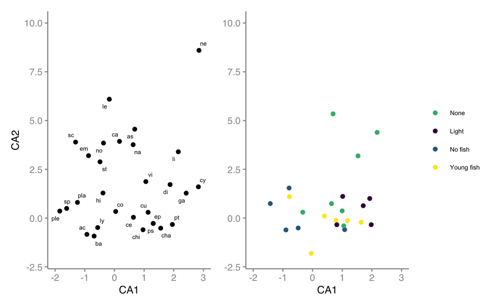

```r
p3c
```